# Statistics Homework

Niall Horan

January 17, 2019

## Lesson 1

### 1.13

Find the mean and median of 123,116,122,110,175,126,125,111,118,117.
$$\bar{x}=\frac{123+116+\dots +117}{10}=124.3$$
$$\tilde x=110,111,116,117,\textbf{118,122},123,125,126,175=120$$

```r
x<-c(110,111,116,117,118,122,123,125,126,175)
mean(x)
```

```
## [1] 124.3
```

```r
median(x)
```

```
## [1] 120
```

Notice the difference between the two. The mean is larger because the value of 175.

### 1.14

data set is 572,572,573,568,569,575,565,570.

#### a. Find the mean and median.

$$\bar{x}=\frac{572+572+\dots +570}{8}=570.5$$
$$\tilde x=565,568,569,\textbf{570,572},572,573,575=571$$

#### b. Find the sample variance, standard deviation, and range.

$$s^2=\sum_{i=1}^n\frac{(x_i-\bar{x})^2}{n-1}=\frac{1}{7}[(565-570.5)^2+(568-570.5)^2+\dots +(575-570.5)^2]=10$$
$$s=\sqrt{10}=3.16$$

```r
x<-c(572,572,573,568,569,575,565,570)
mean(x)
```

```
## [1] 570.5
```

```r
median(x)
```

```
## [1] 571
```

```r
var(x)
```

```
## [1] 10
```

```r
sd(x)
```

```
## [1] 3.162278
```

```r
range(x)
```

```
## [1] 565 575
```

#### c. Although the average is slightly greater than 570, the standard deviation shows that a good amount of tires will be substantailly less than 570 or greater than 570.

## Lesson 2

### 1.18

1. Stem and Leaf
2. histogram
3. mean, median and standard deviation.

```
##
##   The decimal point is 1 digit(s) to the right of the |
##
##   1 | 057
##   2 | 35
##   3 | 246
##   4 | 1138
##   5 | 22457
##   6 | 00123445779
##   7 | 01244456678899
##   8 | 00011223445589
##   9 | 0258
```

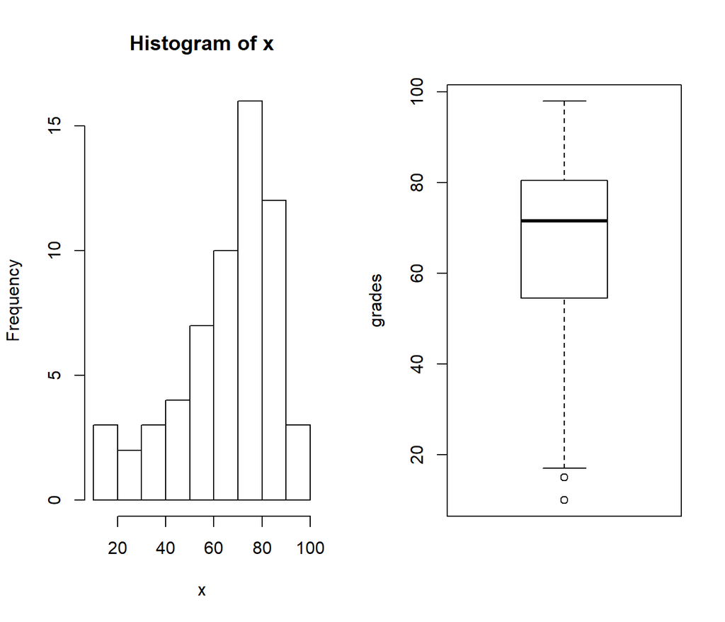

Histogram and Boxplot

```
##       mean median standard.deviation
## 1 65.48333   71.5           21.13355
```

### 1.27

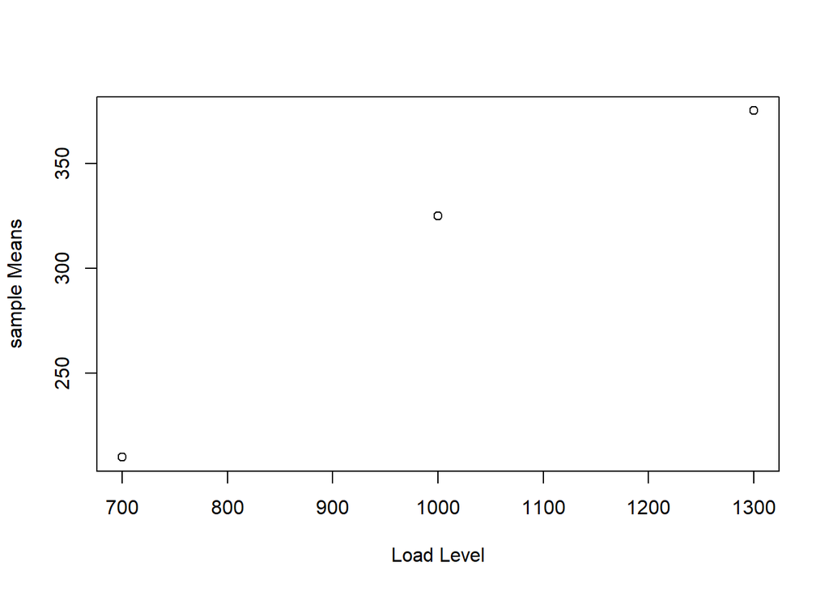

```r
x<-c(700,1000,1300)
y<-c(210,325,375)
plot(x,y, xlab="Load Level", ylab="sample Means")
y1<-c(145,250,150)
y2<-c(105,195,180)
y3<-c(260,375,420)
y4<-c(330,480,750)
df<-data.frame("Level"=x,"y1"=y1,"y2"=y2,"y3"=y3,"y4"=y4)
library(ggplot2)
```

```r
library(tidyr)
library(dplyr)
```

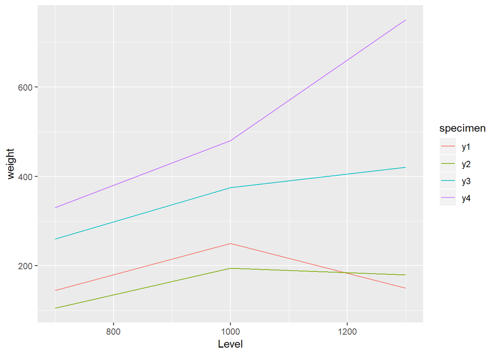

```r
newDF<-gather(data=df,'y1','y2','y3','y4', key='specimen', value='weight')
ggplot(data=newDF,aes(x=Level,y=weight,color=specimen))+geom_line()
```

## Lesson 3.

### 8.17

$$n=16 \hspace{1 cm} \mu=50 \hspace{1 cm} \sigma=5$$
What is the probability
$$\mu_{\bar{x}}-1.9\sigma_\bar{x} <\bar{x}<\mu_{\bar{x}}-0.4\sigma_\bar{x}$$
There are two ways to do this. The easy way is to understand that this is the same as saying $p(-1.9<z<-0.4)$ and using the standard normal we find this to be 0.315.

The other way to do this is the long way using the values given.

$$\mu_{\bar{x}}-1.9\sigma_\bar{x}=50-5*(1.9)/\sqrt{16} \hspace{.25cm} \text{and}\hspace{.25cm} \mu_{\bar{x}}-0.4\sigma_\bar{x}=50-5*(0.4)/\sqrt{16}$$
so now we just want to know the probablity $47.625<\bar{x}<49.5$ Using $z=\frac{\bar{x}-\mu}{\sigma/\sqrt{n}}$

```r
pnorm(-.4,0,1)-pnorm(-1.9,0,1)#easy
```

```
## [1] 0.3158617
```

```r
pnorm(49.5,50,5/4)-pnorm(47.625,50,5/4)#hard
```

```
## [1] 0.3158617
```

#### 8.19

```r
pnorm(175.8,174.5,6.9/5)-pnorm(172.5,174.5,6.9/5)#b
```

```
## [1] 0.7532808
```

```r
pnorm(172,174.5,6.9/5)#c
```

```
## [1] 0.03502446
```

### 8.25

1. $$\mu=7 years, \hspace{.5cm}\sigma=1 year \hspace{.5cm} n=9\hspace{.5cm} p(6.4<\bar{x}<7.2)$$
   $$P(6.4<\bar{x}<7.2)=P(Z<\frac{7.2-7}{\frac{1}{\sqrt{9}}})-P(Z<\frac{6.4-7}{\frac{1}{\sqrt{9}}})=.69$$

b.$P(\bar{X}>\bar{x})=0.15 = 1-P(Z<\frac{\bar{x}-7}{1/\sqrt{9}}) \hspace{.5cm} Z(.85)=1.036$ so $\bar{x}=7.35$

```r
qnorm(.85,0,1)*(1/3)+7
```

```
## [1] 7.345478
```

### 8.29

```r
mu<-c(72,28)
sigma<-c(10,5)
n<-c(64,100)
df<-data.frame(mu,sigma,n)
dnames<-c('terrier','poodle')
row.names(df)<-dnames
df
```

```
##         mu sigma   n
## terrier 72    10  64
## poodle  28     5 100
```

```r
(72-28-44.2)/sqrt(100/68+25/100)
```

```
## [1] -0.1524725
```

$n=25 \hspace{.5cm} \sigma^2=6 \hspace{.5cm}\text{Normal Population}$

$P(S^2>9.1)$

$\chi^2=\frac{(n-1)s^2}{\sigma^2}=\frac{(25-1)9.1}{6}=36.4$

$P(\chi^2>36.4)=.05 \hspace{.25cm} \nu=24 \text{ from tables}$

$P(3.462<s^2<10.745)$

$p(\frac{(25-1)3.462}{6}<\chi^2<\frac{(25-1)10.745}{6})$

$P(13.85<\chi^2<42.98)\hspace{.25cm}\nu=24$

$.99-.05=.94$

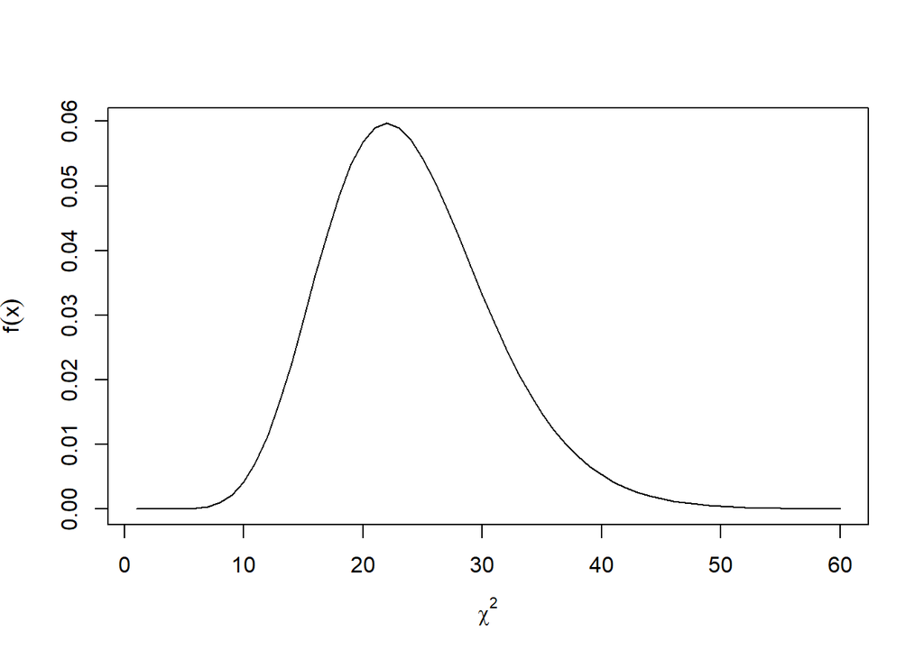

```r
plot(1:60,dchisq(1:60,24), type="l",xlab=expression(chi^2), ylab=expression(f(x)))
```

```r
#a
1-pchisq(36.4,24)
```

```
## [1] 0.0501701
```

```r
#b.
pchisq(42.98,24)-pchisq(13.85,24)
```

```
## [1] 0.9399664
```

### 8.42

$$\chi^2=\frac{(n-1)s^2}{\sigma^2}=\frac{(20-1)20}{8}=47.5$$

$p(\chi^2>47.5)\hspace{.25cm}{\nu=19}\hspace{.25cm}=0.0003$

S it is very unlikely for this to occur!

```r
19*20/8
```

```
## [1] 47.5
```

```r
 1-pchisq(47.5,19)
```

```
## [1] 0.0003028168
```

### 8.49

$\mu=20$ and the sample standard deviation of the mean is unknown se we approximate it with s. $\frac{s}{\sqrt(n)}=\frac{4.1}{\sqrt{9}}=1.4$, so if the standard deviation of the sample mean with $n=9$ is 1.4, to get a mean of 24 is very unlikely(well over two standard deviations aways.)

### 8.50

```r
x<-c(.6,.7,.7,.3,.4,.5,.4,.2)
mean(x)
```

```
## [1] 0.475
```

```r
sd(x)
```

```
## [1] 0.1832251
```

```r
(.475-.5)/.18/sqrt(8)
```

```
## [1] -0.04910464
```

```r
pt(-.05,df=7)
```

```
## [1] 0.4807596
```

### 8.53

```r
m1<-c(8260,8130,8350,8070,8340)
m2<-c(7950,7890,7900,8140,7920,7840)
var(m1)
```

```
## [1] 15750
```

```r
var(m2)
```

```
## [1] 10920
```

## Lesson 5

### 9.2

Need to find the 96% confidence interval.

$\sigma = 40 \hspace{.5cm} n=30 \hspace{.5cm} \bar{x}=780 \hspace{.5cm} \alpha=.04 \hspace{.5cm} z_{\alpha/2}=2.05$

$\bar{x}\pm z_{\alpha/2}\times\sigma/\sqrt{n}$

$780\pm 2.0540\times 40/\sqrt{30}$

$(765.0289 \hspace{.5cm} 794.9711)$

### 9.4

98% confidence interval.

$n=50, \thinspace \bar{x}=174.5, \thinspace \sigma=6.9, \thinspace \alpha=.02$

$\bar{x}\pm z_{\alpha/2}\times\sigma/\sqrt{n}$

$174.5\pm 2.34\times6.9/\sqrt{50}$

$(172.2166, \thinspace 176.7834)$

### 9.7

Solve for n. Error=.0005, $\alpha=.05$ Use thereom 9.2. $n=(\frac{z_{\alpha/2}\times \sigma}{e})^2$ 34.6 or 35

### 9.9

$n<30$ and we do not know populatoin standard deviaton so we are going to use student $t$.$\bar{x}=11.3, \thinspace s=2.45, \thinspace n=20, \thinspace \alpha=.05$
$$\bar{x}\pm t_{\alpha/2}\times s/\sqrt{n}$$
$$\bar{11.3}\pm 2.093\times2.45/\sqrt{20}$$
( 10.15338, 12.44662)

### 9.13

$n<30$ and we do not know populatoin standard deviaton so we are going to use student $t$.$\bar{x}=48.50, \thinspace s=1.5, \thinspace n=12, \thinspace \alpha=.10$
$$\bar{x}\pm t_{\alpha/2}\times s/\sqrt{n}$$

$$48.5\pm 1.80\times 1.5/\sqrt{12}$$
( 47.72236 49.27764)

### 9.17

95% prediction interval from 9.9.$n<30$ and we do not know populatoin standard deviaton so we are going to use student $t$.$\bar{x}=11.3, \thinspace s=2.45, \thinspace n=20, \thinspace \alpha=.05$
$$\bar{x}\pm t_{\alpha/2}\times s\sqrt{1+1/n}$$
$$11.3\pm 2.09\times 2.45\sqrt{1+1/20}$$
(6.053049 16.546951)